# Data Challenge 4: Red Cards and Skin Tone

# Introduction

In this data challenge, we seek to answer the question “Are soccer referees more likely to give red cards to dark skin toned players than light skin toned players?”

The data set consists of information about players, information about the penalty cards they received, and information about the referees who issued the cards.

# Results

```r
library(ggplot2)
library(ggthemes)
library(dplyr)
library(knitr)
library(pscl)
rc <- read.csv('redcard.csv')
head(rc)
```

```
##     playerShort        player            club leagueCountry   birthday
## 1 lucas-wilchez Lucas Wilchez   Real Zaragoza         Spain 31.08.1983
## 2    john-utaka    John Utaka Montpellier HSC        France 08.01.1982
## 3   abdon-prats  AbdÃ³n Prats    RCD Mallorca         Spain 17.12.1992
## 4    pablo-mari   Pablo MarÃ    RCD Mallorca         Spain 31.08.1993
## 5    ruben-pena  RubÃ©n PeÃ±a Real Valladolid         Spain 18.07.1991
## 6  aaron-hughes  Aaron Hughes       Fulham FC       England 08.11.1979
##   height weight             position games victories ties defeats goals
## 1    177     72 Attacking Midfielder     1         0    0       1     0
## 2    179     82         Right Winger     1         0    0       1     0
## 3    181     79                          1         0    1       0     0
## 4    191     87          Center Back     1         1    0       0     0
## 5    172     70     Right Midfielder     1         1    0       0     0
## 6    182     71          Center Back     1         0    0       1     0
##   yellowCards yellowReds redCards   photoID rater1 rater2 refNum
```

[output cut: 20 more lines]

# The Data

All of these data come from the same season, 2012-2013 so I think we can just look at the birth year for age. As a first pass, I will average the ratings for the two raters since they largely agree on skin tone.

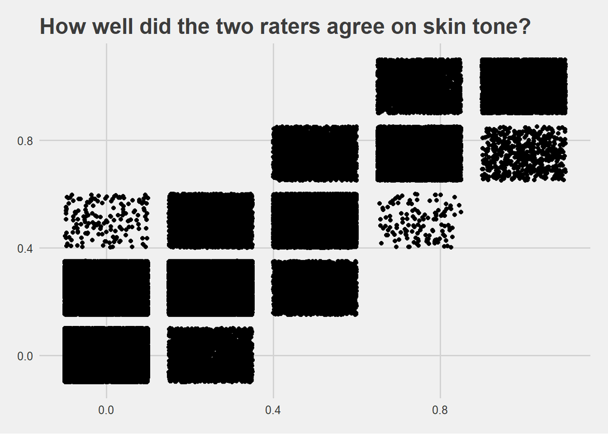

```r
qplot(rater1,rater2,data=rc)+
  geom_jitter()+
  ggtitle('How well did the two raters agree on skin tone?')+
  theme_fivethirtyeight()
```

```r
rc %>%
  mutate(birthday = as.character(birthday),
         birthyear = substr(birthday,7,10),
         mean_rating = (rater1+rater2)/2) ->
  rcm
```

```r
head(rcm)
```

```
##     playerShort        player            club leagueCountry   birthday
## 1 lucas-wilchez Lucas Wilchez   Real Zaragoza         Spain 31.08.1983
## 2    john-utaka    John Utaka Montpellier HSC        France 08.01.1982
## 3   abdon-prats  AbdÃ³n Prats    RCD Mallorca         Spain 17.12.1992
## 4    pablo-mari   Pablo MarÃ    RCD Mallorca         Spain 31.08.1993
## 5    ruben-pena  RubÃ©n PeÃ±a Real Valladolid         Spain 18.07.1991
## 6  aaron-hughes  Aaron Hughes       Fulham FC       England 08.11.1979
##   height weight             position games victories ties defeats goals
## 1    177     72 Attacking Midfielder     1         0    0       1     0
## 2    179     82         Right Winger     1         0    0       1     0
## 3    181     79                          1         0    1       0     0
## 4    191     87          Center Back     1         1    0       0     0
## 5    172     70     Right Midfielder     1         1    0       0     0
## 6    182     71          Center Back     1         0    0       1     0
##   yellowCards yellowReds redCards   photoID rater1 rater2 refNum
```

[output cut: 20 more lines]

| Variable Name | Description |
| --- | --- |
| meanIAT | mean implicit bias score (using the race IAT) for referee country |
| nIAT | sample size for race IAT in that particular country |
| seIAT | standard error for mean estimate of race IAT |
| meanExp | mean explicit bias score (using a racial thermometer task) for referee country |
| nExp | sample size for explicit bias in that particular country |
| seExp | standard error for mean estimate of explicit bias measure |

```r
rcm %>%
  group_by(playerShort) %>%
  summarize(position=unique(position))%>%
  ungroup() %>%
  summarize(missing_positions = sum(position == ''),
            total_players = n(),
            percent_missing = missing_positions/total_players) ->
  player_positions

kable(player_positions)
```

[output not shown]

# Results

There are two ways to look at this problem: 1. From the perspective of the players 2. from the persepctive of the referees

The question is posed in reference to the referees, but it will be useful to look at the players first.

## The Players

First let’s make a plot to answer the question of whether there is a correlation between a players perceived skin tone and the number of red cards they receive:

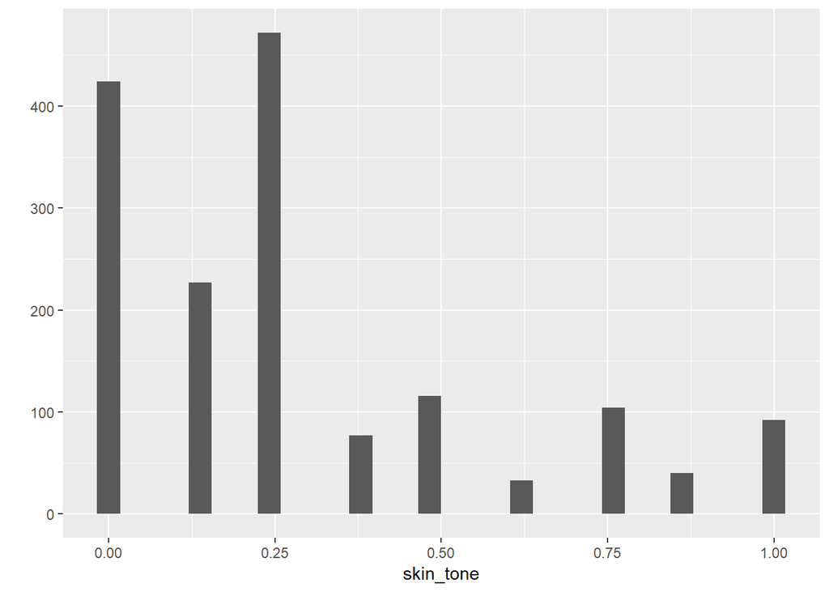

```r
rcm %>%
  group_by(playerShort) %>%
  summarize(total_red_cards = sum(redCards),
            skin_tone = first(mean_rating)) %>%
  mutate(dark = skin_tone <= 0.25,
         light = skin_tone >= 0.75)->
  player_summary

player_summary$color = "mixed"
player_summary$color[is.na(player_summary$skin_tone)] = 'missing'
player_summary$color[player_summary$dark] = "dark"
player_summary$color[player_summary$light] = "light"
player_summary$color <- as.factor(player_summary$color)

qplot(skin_tone,data= player_summary)
```

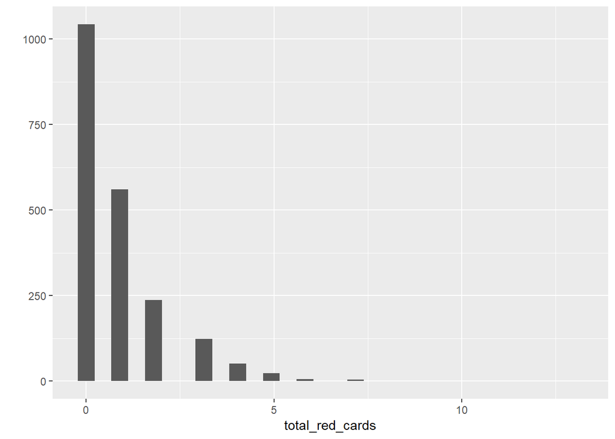

```r
qplot(total_red_cards, data= player_summary)
```

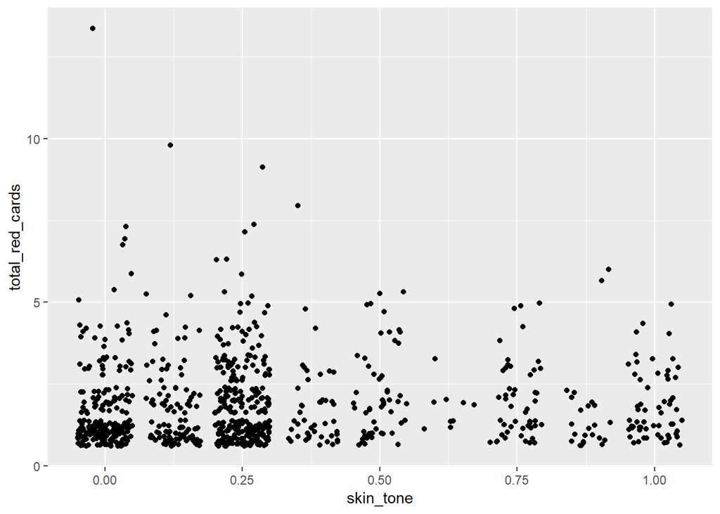

```r
player_summary%>%
  filter(total_red_cards > 0) %>%
  ggplot(aes(skin_tone,total_red_cards))+
  geom_jitter()
```

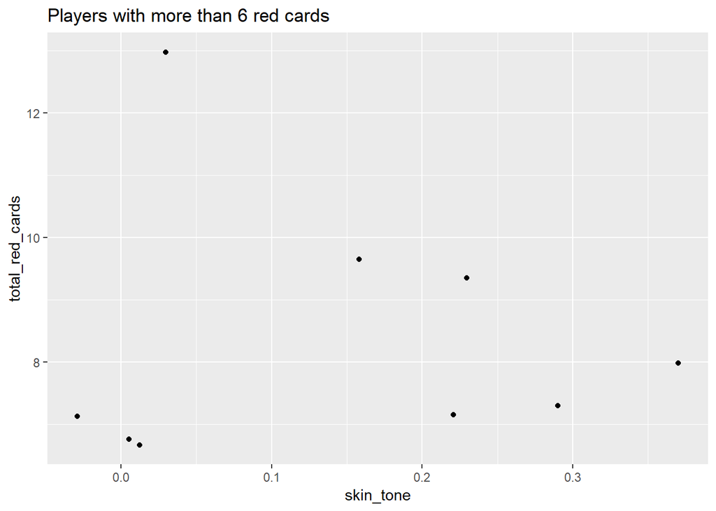

```r
player_summary%>%
  filter(total_red_cards > 6) %>%
  ggplot(aes(skin_tone,total_red_cards))+
  geom_jitter()+
  ggtitle('Players with more than 6 red cards')
```

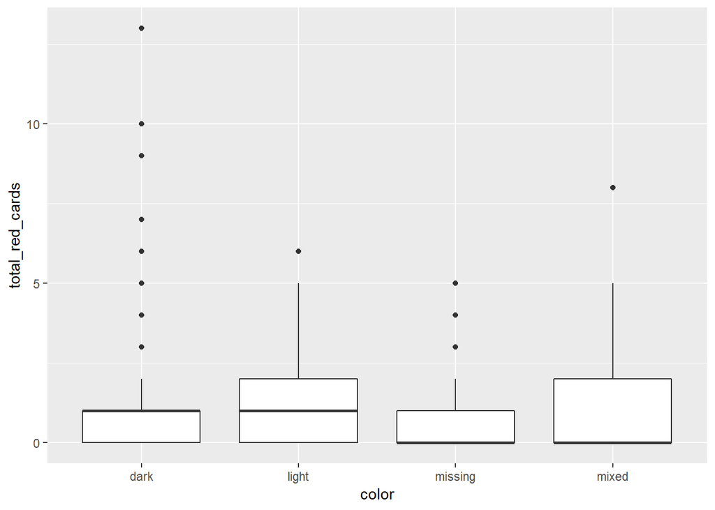

```r
player_summary %>%
  ggplot(aes(color,total_red_cards))+
  geom_boxplot()
```

```r
player_summary %>%
  group_by(color) %>%
  tally()
```

```
## # A tibble: 4 x 2
##   color       n
##   <fct>   <int>
## 1 dark     1123
## 2 light     236
## 3 missing   468
## 4 mixed     226
```

## Referees

Now let’s group by referees and see whether individual referees are more likely to give red cards to darker skinned players.

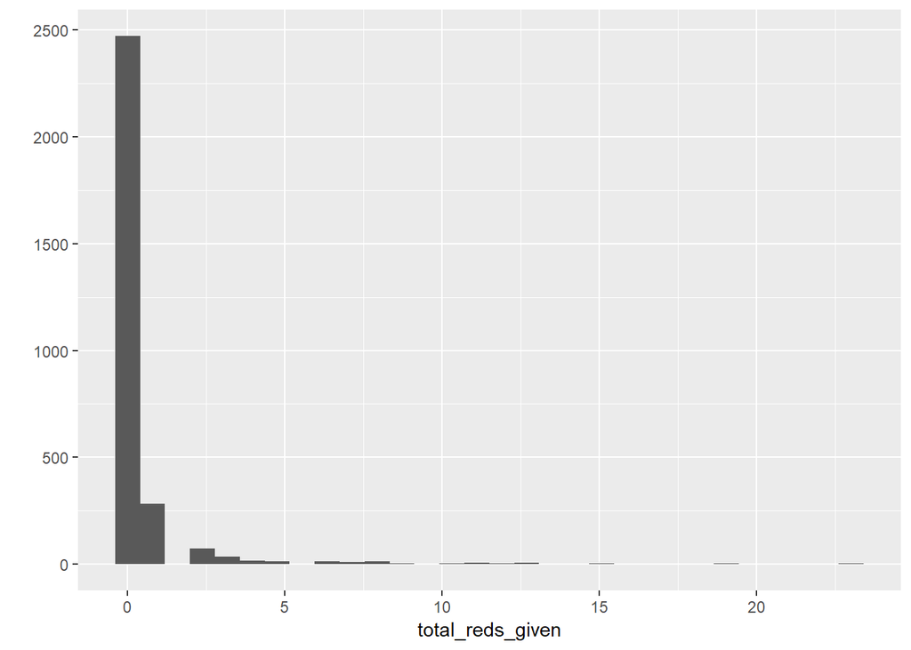

```r
rcm %>%
  filter(!is.na(mean_rating)) %>%
  group_by(refNum) %>%
  summarize(total_reds_given = sum(redCards),
            total_reds_light = sum(redCards[mean_rating<= 0.25]),
            total_reds_dark = sum(redCards[mean_rating>= 0.75]))->
  ref_summary

qplot(total_reds_given,data=ref_summary)
```

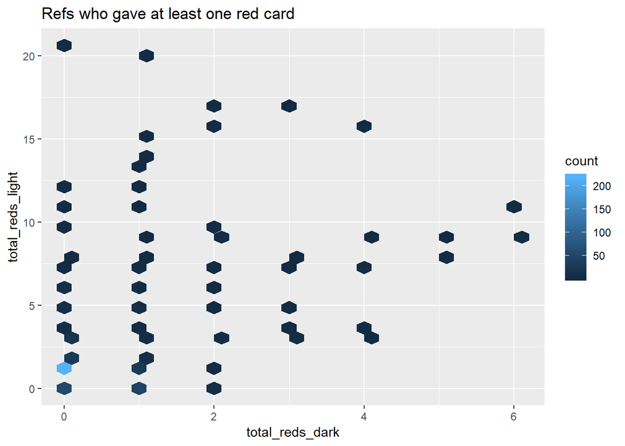

```r
ggplot(ref_summary %>% filter(total_reds_given > 0),
       aes(total_reds_dark, total_reds_light))+
  geom_hex()+
  ggtitle("Refs who gave at least one red card")
```

Most refs never give out any red cards. Of those who do give out red cards, most give one red card to a player who was rated to have lighter skin and none to any players rated to have darker skin.

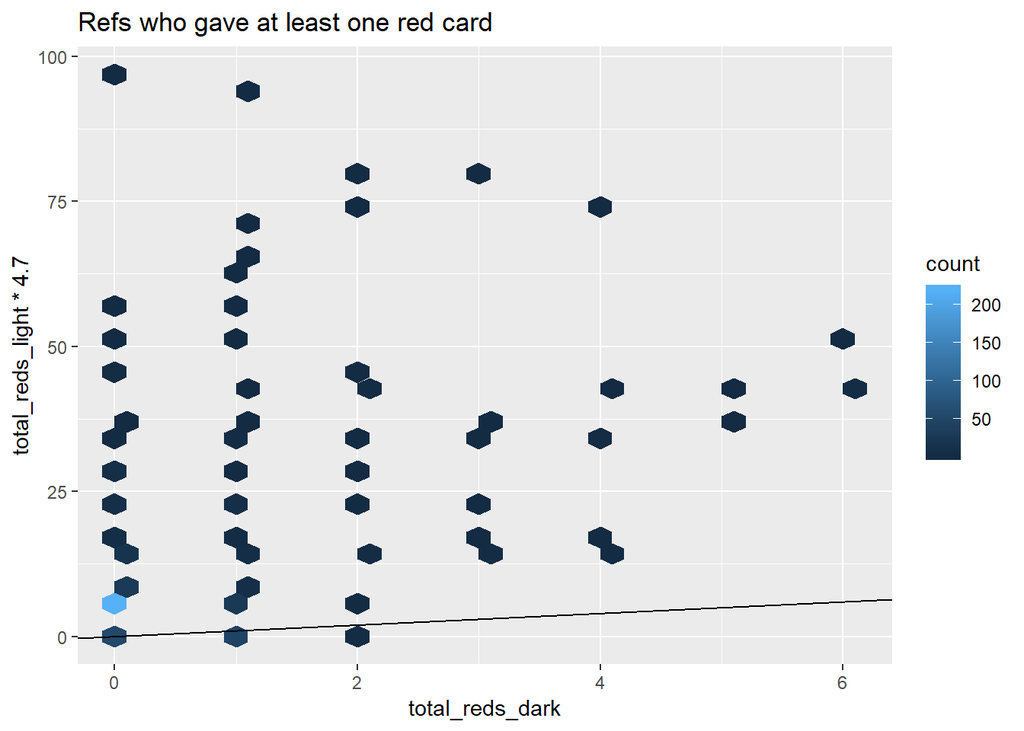

```r
ggplot(ref_summary %>% filter(total_reds_given > 0),
       aes(total_reds_dark, total_reds_light*4.7))+
  geom_hex()+
  geom_abline()+
  ggtitle("Refs who gave at least one red card")
```

```r
rcm %>%
  mutate(binary_redCards = redCards >= 1) ->
  rcm
m <- glm(binary_redCards~mean_rating,data = rcm, family='binomial')
summary(m)
```

```
##
## Call:
## glm(formula = binary_redCards ~ mean_rating, family = "binomial",
##     data = rcm)
##
## Deviance Residuals:
##     Min       1Q   Median       3Q      Max
## -0.1731  -0.1605  -0.1582  -0.1534   2.9826
##
## Coefficients:
##             Estimate Std. Error  z value Pr(>|z|)
## (Intercept) -4.43609    0.03624 -122.421  < 2e-16 ***
## mean_rating  0.24291    0.08488    2.862  0.00421 **
## ---
## Signif. codes:  0 '***' 0.001 '**' 0.01 '*' 0.05 '.' 0.1 ' ' 1
##
## (Dispersion parameter for binomial family taken to be 1)
##
##     Null deviance: 16811  on 124620  degrees of freedom
## Residual deviance: 16804  on 124619  degrees of freedom
##   (21407 observations deleted due to missingness)
## AIC: 16808
##
## Number of Fisher Scoring iterations: 7
```

```r
player_summary %>%
  mutate(any_red = total_red_cards >0) ->
  player_summary

m <- glm(any_red ~ color, data= player_summary, family = 'binomial')
summary(m)
```

```
##
## Call:
## glm(formula = any_red ~ color, family = "binomial", data = player_summary)
##
## Deviance Residuals:
##     Min       1Q   Median       3Q      Max
## -1.2953  -1.2332  -0.9431   1.1226   1.4314
##
## Coefficients:
##              Estimate Std. Error z value Pr(>|z|)
## (Intercept)   0.13019    0.05981   2.177   0.0295 *
## colorlight    0.14267    0.14437   0.988   0.3230
## colormissing -0.71001    0.11341  -6.260 3.84e-10 ***
## colormixed   -0.18330    0.14591  -1.256   0.2090
## ---
## Signif. codes:  0 '***' 0.001 '**' 0.01 '*' 0.05 '.' 0.1 ' ' 1
##
## (Dispersion parameter for binomial family taken to be 1)
##
##     Null deviance: 2845.5  on 2052  degrees of freedom
## Residual deviance: 2799.1  on 2049  degrees of freedom
## AIC: 2807.1
##
## Number of Fisher Scoring iterations: 4
```

```r
m <- glm(total_red_cards ~ dark, data= player_summary %>%
           filter(color != 'missing'), family = 'poisson')
summary(m)
```

```
##
## Call:
## glm(formula = total_red_cards ~ dark, family = "poisson", data = player_summary %>%
##     filter(color != "missing"))
##
## Deviance Residuals:
##     Min       1Q   Median       3Q      Max
## -1.4340  -1.4085  -0.0279   0.0080   6.5484
##
## Coefficients:
##             Estimate Std. Error z value Pr(>|z|)
## (Intercept)  0.02775    0.04588   0.605    0.545
## darkTRUE    -0.03580    0.05480  -0.653    0.514
##
## (Dispersion parameter for poisson family taken to be 1)
##
##     Null deviance: 2607.1  on 1584  degrees of freedom
## Residual deviance: 2606.6  on 1583  degrees of freedom
## AIC: 4646.5
##
## Number of Fisher Scoring iterations: 5
```

```r
#zero inflated poisson model?
m <- zeroinfl(total_red_cards ~ skin_tone, data= player_summary %>%
           filter(color != 'missing'))
summary(m)
```

```
##
## Call:
## zeroinfl(formula = total_red_cards ~ skin_tone, data = player_summary %>%
##     filter(color != "missing"))
##
## Pearson residuals:
##      Min       1Q   Median       3Q      Max
## -0.88077 -0.83271 -0.06536  0.03967 10.32153
##
## Count model coefficients (poisson with log link):
##             Estimate Std. Error z value Pr(>|z|)
## (Intercept)  0.32350    0.04788   6.756 1.41e-11 ***
## skin_tone    0.13501    0.10851   1.244    0.213
##
## Zero-inflation model coefficients (binomial with logit link):
##             Estimate Std. Error z value Pr(>|z|)
## (Intercept)  -0.8006     0.1299  -6.163 7.12e-10 ***
## skin_tone    -0.1096     0.3034  -0.361    0.718
## ---
## Signif. codes:  0 '***' 0.001 '**' 0.01 '*' 0.05 '.' 0.1 ' ' 1
##
## Number of iterations in BFGS optimization: 15
## Log-likelihood: -2236 on 4 Df
```

```r
m <- glm(any_red ~ skin_tone, data= player_summary %>% filter(color != 'missing'), family = 'binomial')
summary(m)
```

```
##
## Call:
## glm(formula = any_red ~ skin_tone, family = "binomial", data = player_summary %>%
##     filter(color != "missing"))
##
## Deviance Residuals:
##    Min      1Q  Median      3Q     Max
## -1.292  -1.228   1.067   1.128   1.149
##
## Coefficients:
##             Estimate Std. Error z value Pr(>|z|)
## (Intercept)  0.06774    0.07100   0.954    0.340
## skin_tone    0.19849    0.17365   1.143    0.253
##
## (Dispersion parameter for binomial family taken to be 1)
##
##     Null deviance: 2191.1  on 1584  degrees of freedom
## Residual deviance: 2189.8  on 1583  degrees of freedom
## AIC: 2193.8
##
## Number of Fisher Scoring iterations: 3
```

```r
rcm %>%
  filter(!is.na(mean_rating)) %>%
  group_by(refNum) %>%
  summarize(total_reds_given = sum(redCards),
            total_reds_light = sum(redCards[mean_rating<= 0.25]),
            total_reds_dark = sum(redCards[mean_rating>= 0.75]),
            meanIAT = first(meanIAT),
            meanExp = first(meanExp),
            dark_reds_proportion = total_reds_dark/total_reds_given) ->
  ref_summary

ref_summary$refNum<- as.factor(ref_summary$refNum)
```

```r
m <- glm(dark_reds_proportion ~ meanIAT,data = ref_summary, family = 'gaussian')
summary(m)
```

```
##
## Call:
## glm(formula = dark_reds_proportion ~ meanIAT, family = "gaussian",
##     data = ref_summary)
##
## Deviance Residuals:
##      Min        1Q    Median        3Q       Max
## -0.40335  -0.17923  -0.12714   0.00258   0.94454
##
## Coefficients:
##             Estimate Std. Error t value Pr(>|t|)
## (Intercept)   0.7064     0.1815   3.893 0.000112 ***
## meanIAT      -1.5659     0.5162  -3.034 0.002540 **
## ---
## Signif. codes:  0 '***' 0.001 '**' 0.01 '*' 0.05 '.' 0.1 ' ' 1
##
## (Dispersion parameter for gaussian family taken to be 0.09055299)
##
##     Null deviance: 46.653  on 507  degrees of freedom
## Residual deviance: 45.820  on 506  degrees of freedom
##   (2470 observations deleted due to missingness)
## AIC: 225.51
##
## Number of Fisher Scoring iterations: 2
```

```r
m <- glm(dark_reds_proportion ~ meanExp,data = ref_summary, family = 'gaussian')
summary(m)
```

```
##
## Call:
## glm(formula = dark_reds_proportion ~ meanExp, family = "gaussian",
##     data = ref_summary)
##
## Deviance Residuals:
##      Min        1Q    Median        3Q       Max
## -0.26945  -0.17270  -0.14328   0.00254   0.94505
##
## Coefficients:
##             Estimate Std. Error t value Pr(>|t|)
## (Intercept)  0.21793    0.03541   6.154 1.54e-09 ***
## meanExp     -0.12690    0.06867  -1.848   0.0652 .
## ---
## Signif. codes:  0 '***' 0.001 '**' 0.01 '*' 0.05 '.' 0.1 ' ' 1
##
## (Dispersion parameter for gaussian family taken to be 0.09158177)
##
##     Null deviance: 46.653  on 507  degrees of freedom
## Residual deviance: 46.340  on 506  degrees of freedom
##   (2470 observations deleted due to missingness)
## AIC: 231.25
##
## Number of Fisher Scoring iterations: 2
```